# ASSIGNMENT 7 - DATA MINING PROJECT

### IS 6482-091 SUMMER 2023 DATA MINING

### BY DEBAYAN DUTTA [U1427957]

### DATE: JULY-23-2023

PROJECT IDEA: This project takes into consideration multiple classification models, that predicts whether a new customer earning from a particualr demography is above 50k or below and if so should the company engage resources in pursuing the customer to sell their new products.

BUSINESS PROBLEM: Identify customers for new product sale.

ANALYTICAL GOAL: Engineer classification models to predict prospect customer income and devise a single model based on performance metrics.

#### IMPORT NECESSARY PACKAGES

```python
import pandas as pd
import numpy as np
import matplotlib as mpl
import matplotlib.pyplot as plt
from sklearn.model_selection import train_test_split
from sklearn.model_selection import cross_val_score
from sklearn.ensemble import RandomForestClassifier
from sklearn.metrics import accuracy_score
from sklearn.preprocessing import PolynomialFeatures
from sklearn.linear_model import LogisticRegression
from sklearn.metrics import accuracy_score, roc_auc_score
from sklearn.metrics import accuracy_score, roc_auc_score, confusion_matrix,classification_report
from sklearn.utils import resample
from sklearn.ensemble import VotingClassifier
from sklearn.naive_bayes import GaussianNB
import seaborn as sns

# Additional configurations or settings
import warnings
warnings.filterwarnings('ignore')
%matplotlib inline
```

### TASK I: EXPLORATORY DATA ANALYSIS

#### READING INPUT DATA AND DISPLAYING ITS FEATURES

```python
# READ INPUT DATASET

data = pd.read_csv("census.csv")
```

```python
# PRINT FIRST 10 ROWS OF INPUT DATA

data.head(10)
```

|  | age | workclass | fnlwgt | education | education-num | marital-status | occupation | relationship | race | sex | capital-gain | capital-loss | hours-per-week | native-country | y |
| --- | --- | --- | --- | --- | --- | --- | --- | --- | --- | --- | --- | --- | --- | --- | --- |
| 0 | 39 | State-gov | 77516 | Bachelors | 13 | Never-married | Adm-clerical | Not-in-family | White | Male | 2174 | 0 | 40 | United-States | <=50K |
| 1 | 50 | Self-emp-not-inc | 83311 | Bachelors | 13 | Married-civ-spouse | Exec-managerial | Husband | White | Male | 0 | 0 | 13 | United-States | <=50K |
| 2 | 38 | Private | 215646 | HS-grad | 9 | Divorced | Handlers-cleaners | Not-in-family | White | Male | 0 | 0 | 40 | United-States | <=50K |
| 3 | 53 | Private | 234721 | 11th | 7 | Married-civ-spouse | Handlers-cleaners | Husband | Black | Male | 0 | 0 | 40 | United-States | <=50K |
| 4 | 28 | Private | 338409 | Bachelors | 13 | Married-civ-spouse | Prof-specialty | Wife | Black | Female | 0 | 0 | 40 | Cuba | <=50K |
| 5 | 37 | Private | 284582 | Masters | 14 | Married-civ-spouse | Exec-managerial | Wife | White | Female | 0 | 0 | 40 | United-States | <=50K |
| 6 | 49 | Private | 160187 | 9th | 5 | Married-spouse-absent | Other-service | Not-in-family | Black | Female | 0 | 0 | 16 | Jamaica | <=50K |
| 7 | 52 | Self-emp-not-inc | 209642 | HS-grad | 9 | Married-civ-spouse | Exec-managerial | Husband | White | Male | 0 | 0 | 45 | United-States | >50K |
| 8 | 31 | Private | 45781 | Masters | 14 | Never-married | Prof-specialty | Not-in-family | White | Female | 14084 | 0 | 50 | United-States | >50K |
| 9 | 42 | Private | 159449 | Bachelors | 13 | Married-civ-spouse | Exec-managerial | Husband | White | Male | 5178 | 0 | 40 | United-States | >50K |

```python
# PRINT SHAPE OF INPUT DATA

print("The dataframe shape:", data.shape)
```

```
The dataframe shape: (32561, 15)
```

There are a total of 15 columns and 32561 rows in the input dataset

```python
data.dtypes
```

```
age                int64
workclass         object
fnlwgt             int64
education         object
education-num      int64
marital-status    object
occupation        object
relationship      object
race              object
sex               object
capital-gain       int64
capital-loss       int64
hours-per-week     int64
native-country    object
y                 object
dtype: object
```

```python
data.describe()
```

|  | age | fnlwgt | education-num | capital-gain | capital-loss | hours-per-week |
| --- | --- | --- | --- | --- | --- | --- |
| count | 32561.000000 | 3.256100e+04 | 32561.000000 | 32561.000000 | 32561.000000 | 32561.000000 |
| mean | 38.581647 | 1.897784e+05 | 10.080679 | 1077.648844 | 87.303830 | 40.437456 |
| std | 13.640433 | 1.055500e+05 | 2.572720 | 7385.292085 | 402.960219 | 12.347429 |
| min | 17.000000 | 1.228500e+04 | 1.000000 | 0.000000 | 0.000000 | 1.000000 |
| 25% | 28.000000 | 1.178270e+05 | 9.000000 | 0.000000 | 0.000000 | 40.000000 |
| 50% | 37.000000 | 1.783560e+05 | 10.000000 | 0.000000 | 0.000000 | 40.000000 |
| 75% | 48.000000 | 2.370510e+05 | 12.000000 | 0.000000 | 0.000000 | 45.000000 |
| max | 90.000000 | 1.484705e+06 | 16.000000 | 99999.000000 | 4356.000000 | 99.000000 |

```python
data.info()
```

```
<class 'pandas.core.frame.DataFrame'>
RangeIndex: 32561 entries, 0 to 32560
Data columns (total 15 columns):
 #   Column          Non-Null Count  Dtype
---  ------          --------------  -----
 0   age             32561 non-null  int64
 1   workclass       32561 non-null  object
 2   fnlwgt          32561 non-null  int64
 3   education       32561 non-null  object
 4   education-num   32561 non-null  int64
 5   marital-status  32561 non-null  object
 6   occupation      32561 non-null  object
 7   relationship    32561 non-null  object
 8   race            32561 non-null  object
 9   sex             32561 non-null  object
 10  capital-gain    32561 non-null  int64
 11  capital-loss    32561 non-null  int64
 12  hours-per-week  32561 non-null  int64
 13  native-country  32561 non-null  object
 14  y               32561 non-null  object
dtypes: int64(6), object(9)
memory usage: 3.7+ MB
```

```python
data.nunique()
```

```
age                  73
workclass             9
fnlwgt            21648
education            16
education-num        16
marital-status        7
occupation           15
relationship          6
race                  5
sex                   2
capital-gain        119
capital-loss         92
hours-per-week       94
native-country       42
y                     2
dtype: int64
```

#### IDENTIFYING MISSING VALUES [NULLS/BLANKS]

```python
#Calculate the null count and percentage for all columns
null_counts = data.isnull().sum()
null_percentages = (null_counts / len(data)) * 100

#Create a DataFrame to display the results
null_info = pd.DataFrame({
    'Column': null_counts.index,
    'Null Count': null_counts,
    'Null Percentage': null_percentages
})

#Sort the DataFrame by null percentages in descending order
null_info_sorted = null_info.sort_values('Null Percentage', ascending=False)

#Print the columns with null values and their percentages
print("Columns with null values (sorted by null percentages):")
print(null_info_sorted)
```

```
Columns with null values (sorted by null percentages):
                        Column  Null Count  Null Percentage
age                        age           0              0.0
workclass            workclass           0              0.0
fnlwgt                  fnlwgt           0              0.0
education            education           0              0.0
education-num    education-num           0              0.0
marital-status  marital-status           0              0.0
occupation          occupation           0              0.0
relationship      relationship           0              0.0
race                      race           0              0.0
sex                        sex           0              0.0
capital-gain      capital-gain           0              0.0
capital-loss      capital-loss           0              0.0
hours-per-week  hours-per-week           0              0.0
native-country  native-country           0              0.0
y                            y           0              0.0
```

There are no NULL values in the dataset.

#### INSPECTING TARGET VARIABLE DISTRIBUTION - IS THE DATASET BALANCED OR UNBALANCED

```python
#Value counts of the target variable
target_counts = data['y'].value_counts()

total_samples = len(data)

target_percentages = (target_counts / total_samples) * 100



print(target_counts)
print()
print(target_percentages)
```

```
 <=50K    24720
 >50K      7841
Name: y, dtype: int64

 <=50K    75.919044
 >50K     24.080956
Name: y, dtype: float64
```

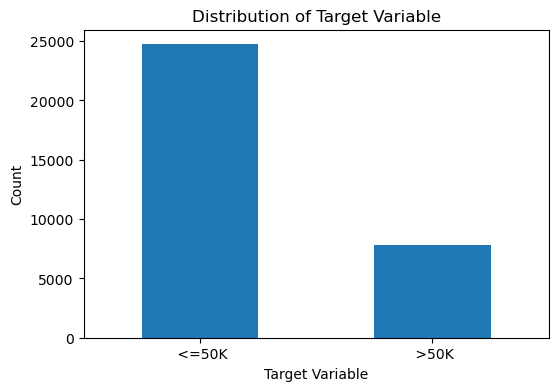

```python
#Visualizing target variable distribution

#Set the figure size
plt.figure(figsize=(6, 4))

#Create the bar plot
target_counts.plot(kind='bar')

#Set the labels and title
plt.xticks(rotation=0)
plt.xlabel('Target Variable')
plt.ylabel('Count')
plt.title('Distribution of Target Variable')

#Show the plot
plt.show()
```

EDA discloses that the target variable is imbalanced with the majority class being thrice the minority class. Considering the dataset size it can be infered that the data set is not huge and there might not be a requirement for sampling of the dataset. We will explore this idea going forward in our data preparation phase.

### TASK II: DATA PREPARATION

```python
# Factoring categorical data

data_1 = data.apply(lambda x: pd.factorize(x)[0] if x.dtype == 'object' else x)
```

```python
data_1.head(10)
```

|  | age | workclass | fnlwgt | education | education-num | marital-status | occupation | relationship | race | sex | capital-gain | capital-loss | hours-per-week | native-country | y |
| --- | --- | --- | --- | --- | --- | --- | --- | --- | --- | --- | --- | --- | --- | --- | --- |
| 0 | 39 | 0 | 77516 | 0 | 13 | 0 | 0 | 0 | 0 | 0 | 2174 | 0 | 40 | 0 | 0 |
| 1 | 50 | 1 | 83311 | 0 | 13 | 1 | 1 | 1 | 0 | 0 | 0 | 0 | 13 | 0 | 0 |
| 2 | 38 | 2 | 215646 | 1 | 9 | 2 | 2 | 0 | 0 | 0 | 0 | 0 | 40 | 0 | 0 |
| 3 | 53 | 2 | 234721 | 2 | 7 | 1 | 2 | 1 | 1 | 0 | 0 | 0 | 40 | 0 | 0 |
| 4 | 28 | 2 | 338409 | 0 | 13 | 1 | 3 | 2 | 1 | 1 | 0 | 0 | 40 | 1 | 0 |
| 5 | 37 | 2 | 284582 | 3 | 14 | 1 | 1 | 2 | 0 | 1 | 0 | 0 | 40 | 0 | 0 |
| 6 | 49 | 2 | 160187 | 4 | 5 | 3 | 4 | 0 | 1 | 1 | 0 | 0 | 16 | 2 | 0 |
| 7 | 52 | 1 | 209642 | 1 | 9 | 1 | 1 | 1 | 0 | 0 | 0 | 0 | 45 | 0 | 1 |
| 8 | 31 | 2 | 45781 | 3 | 14 | 0 | 3 | 0 | 0 | 1 | 14084 | 0 | 50 | 0 | 1 |
| 9 | 42 | 2 | 159449 | 0 | 13 | 1 | 1 | 1 | 0 | 0 | 5178 | 0 | 40 | 0 | 1 |

```python
target_counts_1 = data_1['y'].value_counts()
target_counts_1
```

```
0    24720
1     7841
Name: y, dtype: int64
```

y == <=50K is encoded as 0 and y == >=50k is encoded as 1

```python
data_1.dtypes
```

```
age               int64
workclass         int64
fnlwgt            int64
education         int64
education-num     int64
marital-status    int64
occupation        int64
relationship      int64
race              int64
sex               int64
capital-gain      int64
capital-loss      int64
hours-per-week    int64
native-country    int64
y                 int64
dtype: object
```

#### CORRELATION MATRIX

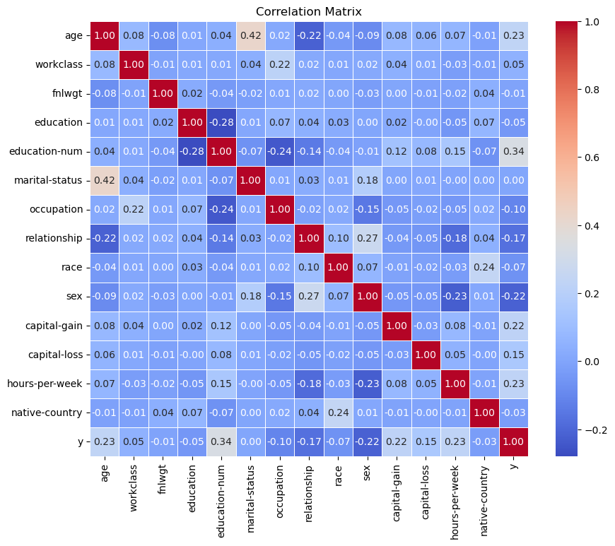

```python
# Defining correlation matrix
correlation_matrix = data_1.corr()

# Create the heatmap using seaborn
plt.figure(figsize=(10, 8))  # Set the size of the plot
sns.heatmap(correlation_matrix, annot=True, cmap='coolwarm', fmt='.2f', linewidths=0.5)

# Add title and display the plot
plt.title("Correlation Matrix")
plt.show()
```

#### SAMPLING DATA SET TO REDUCE IMBALANCE

```python
# Create two dataframes by splitting original dataframe based on target variable value
data_majority = data_1[data_1.y == 0]
data_minority = data_1[data_1.y == 1]
```

```python
print(data_majority.shape)
print(data_minority.shape)
```

```
(24720, 15)
(7841, 15)
```

```python
#Create a new dataframe from majority class by performing undersampling
data_majority_sample = data_majority.sample(n=7841)
```

```python
data_2 = pd.concat([data_majority_sample, data_minority], axis = 0)
```

```python
print(data_2.shape)
```

```
(15682, 15)
```

```python
target_counts_2 = data_2['y'].value_counts()
target_counts_2
```

```
0    7841
1    7841
Name: y, dtype: int64
```

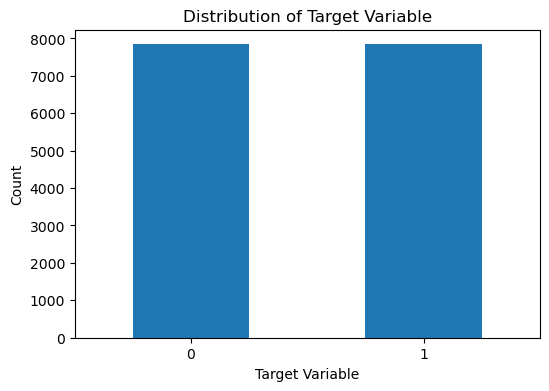

```python
#Visualizing target variable distribution

#Set the figure size
plt.figure(figsize=(6, 4))

#Create the bar plot
target_counts_2.plot(kind='bar')

#Set the labels and title
plt.xticks(rotation=0)
plt.xlabel('Target Variable')
plt.ylabel('Count')
plt.title('Distribution of Target Variable')

#Show the plot
plt.show()
```

We can observe from the correlation matrix that columns "workclass","education","marital-status","race","native-country" does not highly influence the target variable. So we will remove these columns before getting into modelling phase.

```python
columns_to_remove = ["workclass","education","marital-status","race","native-country"]
data_3 = data_2.drop(columns=columns_to_remove)
```

```python
data_3.head(10)
```

|  | age | fnlwgt | education-num | occupation | relationship | sex | capital-gain | capital-loss | hours-per-week | y |
| --- | --- | --- | --- | --- | --- | --- | --- | --- | --- | --- |
| 23198 | 40 | 128700 | 10 | 0 | 4 | 1 | 0 | 0 | 40 | 0 |
| 22018 | 22 | 39615 | 10 | 3 | 0 | 0 | 0 | 0 | 45 | 0 |
| 26262 | 60 | 178792 | 9 | 2 | 0 | 1 | 0 | 0 | 40 | 0 |
| 14823 | 50 | 398625 | 7 | 9 | 0 | 1 | 0 | 0 | 40 | 0 |
| 12203 | 26 | 34393 | 10 | 0 | 0 | 1 | 0 | 0 | 40 | 0 |
| 21367 | 62 | 162678 | 13 | 1 | 1 | 0 | 0 | 0 | 40 | 0 |
| 27205 | 60 | 67320 | 9 | 0 | 0 | 1 | 0 | 0 | 40 | 0 |
| 2803 | 33 | 164190 | 14 | 3 | 3 | 0 | 0 | 0 | 20 | 0 |
| 1794 | 31 | 53042 | 10 | 9 | 1 | 0 | 0 | 0 | 40 | 0 |
| 31238 | 27 | 376150 | 10 | 5 | 0 | 1 | 0 | 0 | 25 | 0 |

#### SPLITTING THE DATASET INTO TRAIN AND TEST DATASETS FOR MODELLING

```python
# "y" is the target variable
X = data_3.drop('y', axis=1)
y = data_3['y']

# Split the data into training and testing sets
X_train, X_test, y_train, y_test = train_test_split(X, y, test_size=0.2, random_state=42)
```

### TASK III: MODELLING

#### MODELS: LOGISTIC REGRESSION, NAIVE BAYE'S MODEL, RANDOM FOREST

```python
# Logistic Regression
logistic_model = LogisticRegression()
logistic_model.fit(X_train, y_train)

# Naive Bayes (Gaussian Naive Bayes)
naive_bayes_model = GaussianNB()
naive_bayes_model.fit(X_train, y_train)

# Random Forest
random_forest_model = RandomForestClassifier(n_estimators=100, random_state=42)
random_forest_model.fit(X_train, y_train)

#Make predictions on Train Set
train_pred_logistic = logistic_model.predict(X_train)
train_pred_naive_bayes = naive_bayes_model.predict(X_train)
train_pred_random_forest = random_forest_model.predict(X_train)

# Make predictions on the test set
y_pred_logistic = logistic_model.predict(X_test)
y_pred_naive_bayes = naive_bayes_model.predict(X_test)
y_pred_random_forest = random_forest_model.predict(X_test)

# Evaluate the models using accuracy as the metric

train_accuracy_logistic = accuracy_score(y_train, train_pred_logistic)
test_accuracy_logistic = accuracy_score(y_test, y_pred_logistic)
print()
train_accuracy_naive_bayes = accuracy_score(y_train, train_pred_naive_bayes)
test_accuracy_naive_bayes = accuracy_score(y_test, y_pred_naive_bayes)
print()
train_accuracy_random_forest = accuracy_score(y_train, train_pred_random_forest)
test_accuracy_random_forest = accuracy_score(y_test, y_pred_random_forest)


print("Logistic Regression Accuracy for train data set:", train_accuracy_logistic)
print("Logistic Regression Accuracy for test data set:", test_accuracy_logistic)
print()
print("Naive Bayes Accuracy for train data set:", train_accuracy_naive_bayes)
print("Naive Bayes Accuracy for test data set:", test_accuracy_naive_bayes)
print()
print("Random Forest Accuracy for train data set:", train_accuracy_random_forest)
print("Random Forest Accuracy for test data set:", test_accuracy_random_forest)
print()
# Confusion Matrix and Performance Metrics
def evaluate_model(model_name, y_true, y_pred):
    print(f"Confusion Matrix for {model_name}:")
    print(confusion_matrix(y_true, y_pred))
    print(f"\nClassification Report for {model_name}:")
    print(classification_report(y_true, y_pred))

# Logistic Regression
evaluate_model("Logistic Regression Train", y_train, train_pred_logistic)
evaluate_model("Logistic Regression Test", y_test, y_pred_logistic)

# Naive Bayes
evaluate_model("Naive Bayes Train", y_train, train_pred_naive_bayes)
evaluate_model("Naive Bayes Test", y_test, y_pred_naive_bayes)

# Random Forest
evaluate_model("Random Forest Train", y_train, train_pred_random_forest)
evaluate_model("Random Forest Test", y_test, y_pred_random_forest)
```

```
Logistic Regression Accuracy for train data set: 0.6216819449980072
Logistic Regression Accuracy for test data set: 0.5996174689193497

Naive Bayes Accuracy for train data set: 0.6330011956954962
Naive Bayes Accuracy for test data set: 0.6232068855594517

Random Forest Accuracy for train data set: 0.999920286966919
Random Forest Accuracy for test data set: 0.8112846668791839

Confusion Matrix for Logistic Regression Train:
[[4374 1912]
 [2834 3425]]

Classification Report for Logistic Regression Train:
              precision    recall  f1-score   support

           0       0.61      0.70      0.65      6286
           1       0.64      0.55      0.59      6259

    accuracy                           0.62     12545
   macro avg       0.62      0.62      0.62     12545
weighted avg       0.62      0.62      0.62     12545

Confusion Matrix for Logistic Regression Test:
[[1054  501]
 [ 755  827]]

Classification Report for Logistic Regression Test:
              precision    recall  f1-score   support

           0       0.58      0.68      0.63      1555
           1       0.62      0.52      0.57      1582

    accuracy                           0.60      3137
   macro avg       0.60      0.60      0.60      3137
weighted avg       0.60      0.60      0.60      3137

Confusion Matrix for Naive Bayes Train:
[[5970  316]
 [4288 1971]]
```

[output cut: 37 more lines]

```
weighted avg       1.00      1.00      1.00     12545

Confusion Matrix for Random Forest Test:
[[1237  318]
 [ 274 1308]]

Classification Report for Random Forest Test:
              precision    recall  f1-score   support

           0       0.82      0.80      0.81      1555
           1       0.80      0.83      0.82      1582

    accuracy                           0.81      3137
   macro avg       0.81      0.81      0.81      3137
weighted avg       0.81      0.81      0.81      3137
```

As we can see the model is highly overfitting in nature, we will perform some hyperparameter tuning and see if we can resolve this issue for the Random Forest Model.

```python
from sklearn.model_selection import GridSearchCV

# Assuming 'X_train' and 'y_train' are the training data
param_grid = {
    'n_estimators': [50, 100, 150],
    'max_depth': [5, 10, 15],
    'min_samples_split': [2, 5, 10],
    'min_samples_leaf': [1, 2, 5],
    'max_features': ['auto', 'sqrt', 'log2']
}

grid_search = GridSearchCV(random_forest_model, param_grid, cv=5)
grid_search.fit(X_train, y_train)

best_params = grid_search.best_params_
best_random_forest_model = grid_search.best_estimator_

print("Best Hyperparameters:", best_params)
```

```
Best Hyperparameters: {'max_depth': 15, 'max_features': 'auto', 'min_samples_leaf': 1, 'min_samples_split': 5, 'n_estimators': 50}
```

```python
# Creating a new random forest model to incorporate the best parameters for model performance

best_random_forest_model = RandomForestClassifier(max_depth=15,
    max_features='auto',
    min_samples_leaf=1,
    min_samples_split=5,
    n_estimators=50, random_state=42)

#Fit the model
best_random_forest_model.fit(X_train, y_train)

#Prediction on train data
train_pred_best_random_forest = best_random_forest_model.predict(X_train)

#prediction on test data
y_pred_best_random_forest = best_random_forest_model.predict(X_test)

#Evaluating accuracy for train and test data
train_accuracy_best_random_forest = accuracy_score(y_train, train_pred_best_random_forest)
test_accuracy_best_random_forest = accuracy_score(y_test, y_pred_best_random_forest)

print('Accuracy of prediction on train data after hyperparameter tuning:', train_accuracy_best_random_forest)
print('Accuracy ofprediction on test data after hyperparameter tuning:', train_accuracy_best_random_forest)

# Random Forest
evaluate_model("Random Forest Train", y_train, train_pred_best_random_forest)
evaluate_model("Random Forest Test", y_test, y_pred_best_random_forest)
```

```
Accuracy of prediction on train data after hyperparameter tuning: 0.8991630131526505
Accuracy ofprediction on test data after hyperparameter tuning: 0.8991630131526505
Confusion Matrix for Random Forest Train:
[[5367  919]
 [ 346 5913]]

Classification Report for Random Forest Train:
              precision    recall  f1-score   support

           0       0.94      0.85      0.89      6286
           1       0.87      0.94      0.90      6259

    accuracy                           0.90     12545
   macro avg       0.90      0.90      0.90     12545
weighted avg       0.90      0.90      0.90     12545

Confusion Matrix for Random Forest Test:
[[1206  349]
 [ 223 1359]]

Classification Report for Random Forest Test:
              precision    recall  f1-score   support

           0       0.84      0.78      0.81      1555
           1       0.80      0.86      0.83      1582

    accuracy                           0.82      3137
   macro avg       0.82      0.82      0.82      3137
weighted avg       0.82      0.82      0.82      3137
```

```python
# Cross-Validation for logistic Regression Model

cv_scores_lr = cross_val_score(logistic_model, X_train, y_train, cv=5)

# Print the cross-validation scores
print(f"Cross-validation scores for Logistic Regression model: {cv_scores_lr}")
print()
print(f"Average cross-validation accuracy for Logistic Regression model: {cv_scores_lr.mean()}")
print()

# Cross-Validation for Naive bayes Model
cv_scores_nb = cross_val_score(naive_bayes_model, X_train, y_train, cv=5)

# Print the cross-validation scores
print()
print(f"Cross-validation scores for Naive Bayes Model: {cv_scores_nb}")
print()
print(f"Average cross-validation accuracy for Naive Bayes Model: {cv_scores_nb.mean()}")
print()

# Cross-Validation for Random Forest Model
cv_scores_rf = cross_val_score(random_forest_model, X_train, y_train, cv=5)

# Print the cross-validation scores
print()
print(f"Cross-validation scores for Random Forest Model: {cv_scores_rf}")
print()
print(f"Average cross-validation accuracy for Random Forest Model: {cv_scores_rf.mean()}")

# Cross-Validation for Random Forest Model after hyperparameter tuning
cv_scores_best_rf = cross_val_score(best_random_forest_model, X_train, y_train, cv=5)

# Print the cross-validation scores
print()
print(f"Cross-validation scores for Random Forest Model after hyperparameter tuning: {cv_scores_best_rf}")
print()
print(f"Average cross-validation accuracy for Random Forest Model after hyperparameter tuning: {cv_scores_best_rf.mean()}")
```

```
Cross-validation scores for Logistic Regression model: [0.65803109 0.62176166 0.62495018 0.62495018 0.62295735]

Average cross-validation accuracy for Logistic Regression model: 0.6305300916699881


Cross-validation scores for Naive Bayes Model: [0.63770426 0.63332005 0.63092866 0.63292148 0.62774014]

Average cross-validation accuracy for Naive Bayes Model: 0.6325229174970108


Cross-validation scores for Random Forest Model: [0.81745715 0.82303707 0.81785572 0.82542846 0.81506576]

Average cross-validation accuracy for Random Forest Model: 0.8197688322040655

Cross-validation scores for Random Forest Model after hyperparameter tuning: [0.83140694 0.8318055  0.8318055  0.83698685 0.82861698]

Average cross-validation accuracy for Random Forest Model after hyperparameter tuning: 0.8321243523316063
```

```python
# Determining the value of each of the features/predictors through feature importance method based on Random forest model.

feature_importance = best_random_forest_model.feature_importances_

# Create a DataFrame to display the feature importances
importance_df = pd.DataFrame({'Feature': X.columns, 'Importance': feature_importance})
importance_df = importance_df.sort_values(by='Importance', ascending=False)

print(importance_df)
```

```
          Feature  Importance
4    relationship    0.278707
2   education-num    0.168050
0             age    0.167674
6    capital-gain    0.107884
8  hours-per-week    0.081079
1          fnlwgt    0.074360
3      occupation    0.055499
7    capital-loss    0.034411
5             sex    0.032337
```

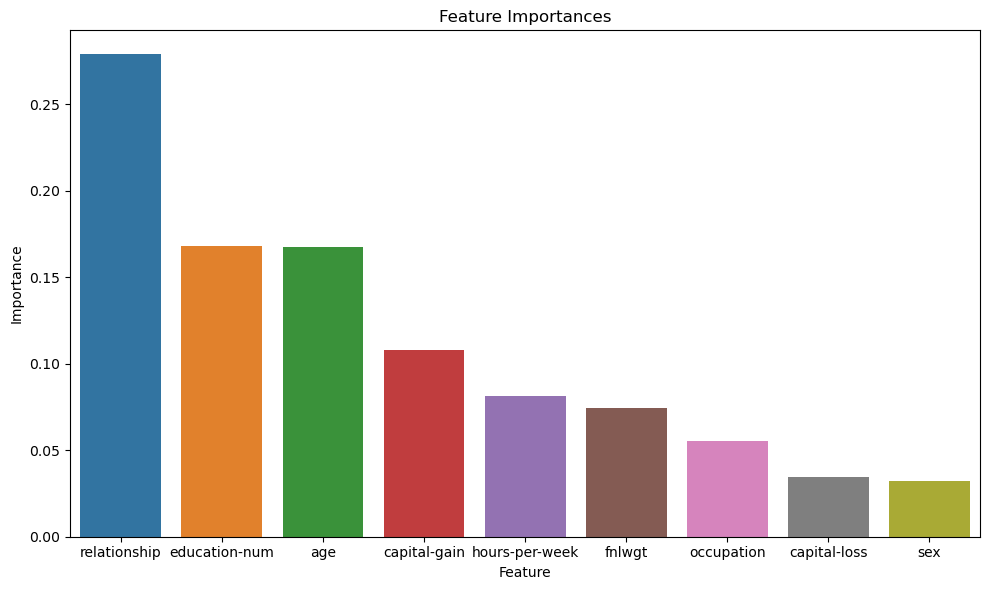

```python
# Using bar plot to visualize the feature importances using Seaborn
plt.figure(figsize=(10, 6))
sns.barplot(data=importance_df, x='Feature', y='Importance')
plt.xticks(rotation=0)
plt.xlabel('Feature')
plt.ylabel('Importance')
plt.title('Feature Importances')
plt.tight_layout()
plt.show()
```

### TASK IV: SUMMARY

For training data, Precision: 94% for class 0 (Negative class), 87% for class 1 (Positive class) Recall: 85% for class 0, 94% for class 1 F1-Score: 89% for class 0, 90% for class 1 The model shows balanced performance on both classes, with good accuracy, precision, and recall scores.

For testing data, Precision: 84% for class 0 (Negative class), 80% for class 1 (Positive class) Recall: 78% for class 0, 86% for class 1 F1-Score: 81% for class 0, 83% for class 1 The model exhibits reasonably good performance on the test data, with similar accuracy, precision, and recall scores.

The Random Forest model identified the most influential features for predicting the target variable. Among the features, the top five most important features in descending order are:

1. relationship (Importance: 27.87%)
2. education-num (Importance: 16.81%)
3. age (Importance: 16.77%)
4. capital-gain (Importance: 10.79%)
5. hours-per-week (Importance: 8.11%)

With this above information about the important features that can and are affecting the income of an individual, the stakeholders can instruct the company's marketing and sales team to come up with a survey for potential customers and give more emphasis on top by predictors/features. The survey should be able to gather more in-depth information about the customer and whether or not they fit the demography and the income range and whether they should be persuade to use the company's product.

The analysis done here is not exhaustive and there is more than can be achieved through data collection and advanced analytical modelling and probable drill down analysis on the top predicted features going forward.